# practical lab1

## Practical Lab 1 - Univariate Linear Regression on the California Housing Prices Dataset

### The goal of the report :

In order to predict the median house value based on three distinct independent variables—median income, population, and number of households—three univariate linear regression models will be developed and analyzed in this report. The goal is to identify which variable has the highest predictive link with the median house value by running different models for each variable. We hope to gain insight into housing market patterns and comprehend the distinct effects of each element through this procedure. By identifying the primary factors influencing house prices, the ultimate goal is to enhance decision-making on investment strategies.

### Obtaining the data :

```python
import pandas as pd

housing = pd.read_csv('C:/Users/ADMIN/Documents/Foundation-Machine-Learning-framework-/data/housing.csv')

housing
```

|  | longitude | latitude | housing_median_age | total_rooms | total_bedrooms | population | households | median_income | median_house_value | ocean_proximity |
| --- | --- | --- | --- | --- | --- | --- | --- | --- | --- | --- |
| 0 | -122.23 | 37.88 | 41.0 | 880.0 | 129.0 | 322.0 | 126.0 | 8.3252 | 452600.0 | NEAR BAY |
| 1 | -122.22 | 37.86 | 21.0 | 7099.0 | 1106.0 | 2401.0 | 1138.0 | 8.3014 | 358500.0 | NEAR BAY |
| 2 | -122.24 | 37.85 | 52.0 | 1467.0 | 190.0 | 496.0 | 177.0 | 7.2574 | 352100.0 | NEAR BAY |
| 3 | -122.25 | 37.85 | 52.0 | 1274.0 | 235.0 | 558.0 | 219.0 | 5.6431 | 341300.0 | NEAR BAY |
| 4 | -122.25 | 37.85 | 52.0 | 1627.0 | 280.0 | 565.0 | 259.0 | 3.8462 | 342200.0 | NEAR BAY |
| ... | ... | ... | ... | ... | ... | ... | ... | ... | ... | ... |
| 20635 | -121.09 | 39.48 | 25.0 | 1665.0 | 374.0 | 845.0 | 330.0 | 1.5603 | 78100.0 | INLAND |
| 20636 | -121.21 | 39.49 | 18.0 | 697.0 | 150.0 | 356.0 | 114.0 | 2.5568 | 77100.0 | INLAND |
| 20637 | -121.22 | 39.43 | 17.0 | 2254.0 | 485.0 | 1007.0 | 433.0 | 1.7000 | 92300.0 | INLAND |
| 20638 | -121.32 | 39.43 | 18.0 | 1860.0 | 409.0 | 741.0 | 349.0 | 1.8672 | 84700.0 | INLAND |
| 20639 | -121.24 | 39.37 | 16.0 | 2785.0 | 616.0 | 1387.0 | 530.0 | 2.3886 | 89400.0 | INLAND |

20640 rows × 10 columns

### Exploratory Data Analysis (EDA) :

```python
housing.describe()
```

|  | longitude | latitude | housing_median_age | total_rooms | total_bedrooms | population | households | median_income | median_house_value |
| --- | --- | --- | --- | --- | --- | --- | --- | --- | --- |
| count | 20640.000000 | 20640.000000 | 20640.000000 | 20640.000000 | 20433.000000 | 20640.000000 | 20640.000000 | 20640.000000 | 20640.000000 |
| mean | -119.569704 | 35.631861 | 28.639486 | 2635.763081 | 537.870553 | 1425.476744 | 499.539680 | 3.870671 | 206855.816909 |
| std | 2.003532 | 2.135952 | 12.585558 | 2181.615252 | 421.385070 | 1132.462122 | 382.329753 | 1.899822 | 115395.615874 |
| min | -124.350000 | 32.540000 | 1.000000 | 2.000000 | 1.000000 | 3.000000 | 1.000000 | 0.499900 | 14999.000000 |
| 25% | -121.800000 | 33.930000 | 18.000000 | 1447.750000 | 296.000000 | 787.000000 | 280.000000 | 2.563400 | 119600.000000 |
| 50% | -118.490000 | 34.260000 | 29.000000 | 2127.000000 | 435.000000 | 1166.000000 | 409.000000 | 3.534800 | 179700.000000 |
| 75% | -118.010000 | 37.710000 | 37.000000 | 3148.000000 | 647.000000 | 1725.000000 | 605.000000 | 4.743250 | 264725.000000 |
| max | -114.310000 | 41.950000 | 52.000000 | 39320.000000 | 6445.000000 | 35682.000000 | 6082.000000 | 15.000100 | 500001.000000 |

Here we used the describe() method to get the mean, std, min values, count of all rows, Max values, and all quartile values the housing data set.

The total number of entries that are not null in each column of the data is represented by count

The average of each digital column is the mean of the data set.

The standard deviation(std) shows the average amount that is split from the mean for each digital column.

The lowest possible number in each column of the data set is represented as Min.

First quartile (25%): Produces the data that falls under 25% data in the data sets.

50% is the second quartile. we can also describe the second quartile as the median.

Third quartile (75%): produces the data that falls under 75% data in the data set.

The highest possible number in each column of the data set is the max value.

### Seaborn scatter plots of median house value vs. median income :

```python
import seaborn as sns
import matplotlib.pyplot as plt
```

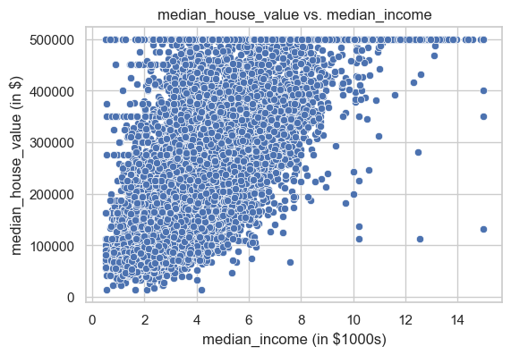

```python
# setting the style
sns.set(style="whitegrid")

# Creating the scatter plot: Median House Value vs. Median Income
plt.figure(figsize=(6, 4)) # creating size of plot
sns.scatterplot(x='median_income', y='median_house_value', data=housing) # Passing the data set values to the code


plt.title('median_house_value vs. median_income') #Adding title to the graph
plt.xlabel('median_income (in $1000s)') # Adding label to the graph to X axis
plt.ylabel('median_house_value (in $)') # Adding label to the Y axis

#Display the graph
plt.show()
```

### Textual Interpretation and Insights of median house value vs. median income : :

**Interpretation :** The scatter plot indicates that the median income and median house value have a positive relationship. Property values are increased based on the income of the users. The housing prices are probably going to be higher in locations with greater median incomes. There is probably a significant positive correlation between Median income and median house values as per the linear regression model.

for example if a person earning the 10000$ to 15000$ their is is probability of buying the house value between 400000$ - 500000$

**Insights :** If their is a more income then their is a probability of higher purchasing power and higher housing prices, median income acts as a important factor of property values.

### Seaborn scatter plots of median house value vs. population :

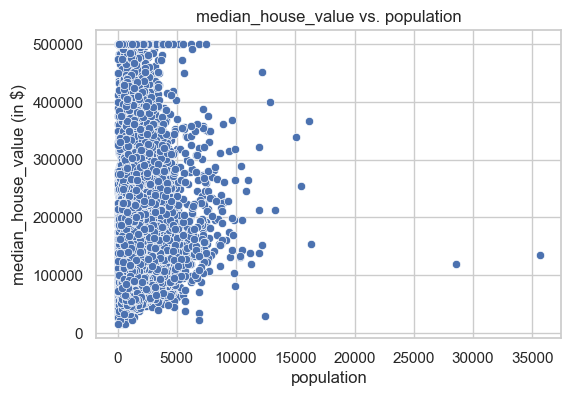

```python
# setting the style
sns.set(style="whitegrid")

# Create the scatter plot: Median House Value vs. Population
plt.figure(figsize=(6, 4)) # creating size of plot
sns.scatterplot(x='population', y='median_house_value', data=housing)

# Add title and labels
plt.title('median_house_value vs. population') #Adding title to the graph
plt.xlabel('population') # Adding label to the graph to X axis
plt.ylabel('median_house_value (in $)') # Adding label to the Y axis

# Show the plot
plt.show()
```

### Textual Interpretation and Insights of median house value vs. Population :

**Interpretation :** The Scatter Plotting shows that the association between the median house value and population size is more irregular and weaker than the relationship between income and median housing value. Because there is no obvious linear trend in this dataset, population may not be a very effective predictor of median house values.

For Example in the above graph if the population is increasing then their is less possibility to buy a higher value of the house.

**Insights :** It's possible that the population-based linear regression model does a poor job of forecasting median home values.It is doubtful that population will have a significant impact on housing prices on its own; instead, other factors, such as income, might.

### Seaborn scatter plots of median house value vs. number of households :

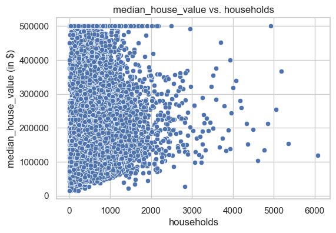

```python
# setting the style
sns.set(style="whitegrid")

# Create the scatter plot: Median House Value vs. Number of Households
plt.figure(figsize=(6, 4)) # creating size of plot
sns.scatterplot(x='households', y='median_house_value', data=housing)

# Add title and labels
plt.title('median_house_value vs. households') #Adding title to the graph
plt.xlabel('households') # Adding label to the graph to X axis
plt.ylabel('median_house_value (in $)') # Adding label to the Y axis

# Show the plot
plt.show()
```

### Textual Interpretation and Insights of median house value vs. Number of Households

**Interpretation :** The scatter plot shows that the relation between the number of households and median house value is weaker and more dispersed when compared to other factors, such as income.Because there is no obvious linear trend in this dataset, the number of households may not be a trustworthy indication of median house values. The wide range of points indicates that factors other than the number of households probably have a stronger impact on home prices.

**Insights :** The dispersed arrangement of the data points leads to a little or nonexistent relationship between the number of households and the median home value.

### Variables Used in This Lab:

1. **Median House Value (Dependent Variable):**

   **Meaning:** The average price of homes in a certain location.

   **Range:** This Usually varies based on the area, potentially ranging from affordable to really big house.

   **Characteristics:** Probably biassed in some locations because of anomalies, such as upscale real estate. Maybe not distributed normally.
2. **Median Income (Independent Variable):**

   **Meaning:** The average wage per family in a given region.

   **Range:** Usually represented in thousands of dollars; Here, with higher levels of income, there will be higher costs of housing.

   **Characteristics:** It has a positive relationship with the housing costs and explains property prices with great accuracy most of the time.
3. **Population (Independent Variable):**

   **Meaning:** A total population refers to people occupying a given region

   **Range:** It can be from rural to urban depending on the density of the population level within a certain area.

   **Characteristics:** Here we have a poor correlation with the house prices as evidenced by the locations of the plots which show very little interaction with them.
4. **Number of Households (Independent Variable):**

   **Meaning:** The total of all the families that may reside in a certain region.

   **Range:** It Covers from small group of people to large complex containing many houses in major the areas.

### Run three linear regressions (fitting) between :

median house value vs. median income

median house value vs. population

median house value vs. number of households.

```python
import statsmodels.api as sm
def linearregression(dependent_var, independent_var):
    X = housing[independent_var]
    y = housing[dependent_var]

    # Add a constant to the model (intercept)
    X = sm.add_constant(X)

    # Fit the model
    model = sm.OLS(y, X).fit()

    # Print the summary
    print(model.summary())
```

### Linear regression between median house value vs. median income :

```python
linearregression('median_house_value', 'median_income') # Running linear regression between median house value vs. median income
```

```
                            OLS Regression Results
==============================================================================
Dep. Variable:     median_house_value   R-squared:                       0.473
Model:                            OLS   Adj. R-squared:                  0.473
Method:                 Least Squares   F-statistic:                 1.856e+04
Date:                Sun, 22 Sep 2024   Prob (F-statistic):               0.00
Time:                        11:46:27   Log-Likelihood:            -2.6325e+05
No. Observations:               20640   AIC:                         5.265e+05
Df Residuals:                   20638   BIC:                         5.265e+05
Df Model:                           1
Covariance Type:            nonrobust
=================================================================================
                    coef    std err          t      P>|t|      [0.025      0.975]
---------------------------------------------------------------------------------
const          4.509e+04   1322.872     34.082      0.000    4.25e+04    4.77e+04
median_income  4.179e+04    306.806    136.223      0.000    4.12e+04    4.24e+04
==============================================================================
Omnibus:                     4245.795   Durbin-Watson:                   0.655
Prob(Omnibus):                  0.000   Jarque-Bera (JB):             9273.446
Skew:                           1.191   Prob(JB):                         0.00
Kurtosis:                       5.260   Cond. No.                         10.2
==============================================================================

Notes:
[1] Standard Errors assume that the covariance matrix of the errors is correctly specified.
```

### Linear regression between median house value vs. Population

```python
linearregression('median_house_value', 'population') # Running linear regression between median house values vs. Population
```

```
                            OLS Regression Results
==============================================================================
Dep. Variable:     median_house_value   R-squared:                       0.001
Model:                            OLS   Adj. R-squared:                  0.001
Method:                 Least Squares   F-statistic:                     12.55
Date:                Sun, 22 Sep 2024   Prob (F-statistic):           0.000398
Time:                        11:46:31   Log-Likelihood:            -2.6986e+05
No. Observations:               20640   AIC:                         5.397e+05
Df Residuals:                   20638   BIC:                         5.397e+05
Df Model:                           1
Covariance Type:            nonrobust
==============================================================================
                 coef    std err          t      P>|t|      [0.025      0.975]
------------------------------------------------------------------------------
const       2.104e+05   1290.927    163.012      0.000    2.08e+05    2.13e+05
population    -2.5118      0.709     -3.542      0.000      -3.902      -1.122
==============================================================================
Omnibus:                     2387.069   Durbin-Watson:                   0.308
Prob(Omnibus):                  0.000   Jarque-Bera (JB):             3301.867
Skew:                           0.967   Prob(JB):                         0.00
Kurtosis:                       3.311   Cond. No.                     2.93e+03
==============================================================================

Notes:
[1] Standard Errors assume that the covariance matrix of the errors is correctly specified.
[2] The condition number is large, 2.93e+03. This might indicate that there are
strong multicollinearity or other numerical problems.
```

### Linear regression between median house value vs.Number of household :

```python
linearregression('median_house_value', 'households') # Running linear regression between house value vs. Number of house holds
```

```
                            OLS Regression Results
==============================================================================
Dep. Variable:     median_house_value   R-squared:                       0.004
Model:                            OLS   Adj. R-squared:                  0.004
Method:                 Least Squares   F-statistic:                     89.86
Date:                Sun, 22 Sep 2024   Prob (F-statistic):           2.82e-21
Time:                        11:46:34   Log-Likelihood:            -2.6982e+05
No. Observations:               20640   AIC:                         5.397e+05
Df Residuals:                   20638   BIC:                         5.397e+05
Df Model:                           1
Covariance Type:            nonrobust
==============================================================================
                 coef    std err          t      P>|t|      [0.025      0.975]
------------------------------------------------------------------------------
const       1.969e+05   1318.748    149.330      0.000    1.94e+05       2e+05
households    19.8728      2.096      9.479      0.000      15.764      23.982
==============================================================================
Omnibus:                     2520.280   Durbin-Watson:                   0.322
Prob(Omnibus):                  0.000   Jarque-Bera (JB):             3541.913
Skew:                           0.998   Prob(JB):                         0.00
Kurtosis:                       3.370   Cond. No.                     1.04e+03
==============================================================================

Notes:
[1] Standard Errors assume that the covariance matrix of the errors is correctly specified.
[2] The condition number is large, 1.04e+03. This might indicate that there are
strong multicollinearity or other numerical problems.
```

### In a single table for all three linear regressions, provide per regression model

intercept and slope

Mean Squared Error

Mean Absolute Error

```python
housing_preprocessed = housing[housing.median_house_value != 500001]
```

```python
train_size = int(len(housing_preprocessed) * 0.8)
train = housing_preprocessed[:train_size]
test = housing_preprocessed[train_size:]
```

```python
#creating models
from sklearn import linear_model
model = linear_model.LinearRegression()
model1 = linear_model.LinearRegression()
model2 = linear_model.LinearRegression()
```

```python
# performing linear regression
model.fit(X=train[["median_income"]], y=train[["median_house_value"]]) # model for the median_house_value vs.median_income
model1.fit(X=train[["population"]],y =train[["median_house_value"]]) # Model for the the median_house_value vs. population
model2.fit(X=train[["households"]],y =train[["median_house_value"]] ) # Model for the median_house_value vs.household
```

```
LinearRegression()
```

```python
from sklearn.metrics import mean_squared_error, mean_absolute_error
import io
import sys
from tabulate import tabulate

# Function fo the storing the result
def capture_results(func):
    old_stdout = sys.stdout
    new_stdout = io.StringIO()
    sys.stdout = new_stdout
    func()
    sys.stdout = old_stdout
    return new_stdout.getvalue()

# store the result in the form of list
results = []

# Defining functions for median_income
def median_income():
    results.append(["Median Income", model.intercept_, model.coef_[0],
                    mean_squared_error(train[['median_house_value']], model.predict(train[['median_income']])),
                    mean_absolute_error(train[['median_house_value']], model.predict(train[['median_income']]))])

def population(): #Defining function for population
    results.append(["Population", model1.intercept_, model1.coef_[0],
                    mean_squared_error(train[['median_house_value']], model1.predict(train[['population']])),
                    mean_absolute_error(train[['median_house_value']], model1.predict(train[['population']]))])

def household(): # Defining function for the household
    results.append(["Households", model2.intercept_, model2.coef_[0],
                    mean_squared_error(train[['median_house_value']], model2.predict(train[['households']])),
                    mean_absolute_error(train[['median_house_value']], model2.predict(train[['households']]))])

# Calling all functions
median_income()
population()
household()

# Defining headers
headers = ["Independent variables", "Intercept", "Slope", "Mean Squared Error", "Mean Absolute Error"]

# Print the table
print(tabulate(results, headers, tablefmt="grid"))
```

```
+-------------------------+-------------+-------------+----------------------+-----------------------+
| Independent variables   |   Intercept |       Slope |   Mean Squared Error |   Mean Absolute Error |
+=========================+=============+=============+======================+=======================+
| Median Income           |     48204.5 | 38703       |          5.55795e+09 |               55840   |
+-------------------------+-------------+-------------+----------------------+-----------------------+
| Population              |    188082   |     0.32863 |          9.23619e+09 |               75879.5 |
+-------------------------+-------------+-------------+----------------------+-----------------------+
| Households              |    177147   |    22.6257  |          9.1569e+09  |               75463.1 |
+-------------------------+-------------+-------------+----------------------+-----------------------+
```

#### Plot the resulting line on top of the scatter data for each of the three models (three separate graphs), add the line parameters (intercept and slope), MSE and MAE to the graph (you can use a text box). You can use any plotting library for that (Matplotlib, Seaborn or Plotly)

### Plotting the line on top of scatter data for median house value vs. median income :

```python
12*model.coef_ + model.intercept_
```

```
array([[512640.20242926]])
```

```python
model.predict(X=[[12],[1],[100]])
```

```
array([[ 512640.20242926],
       [  86907.50670659],
       [3918501.76821055]])
```

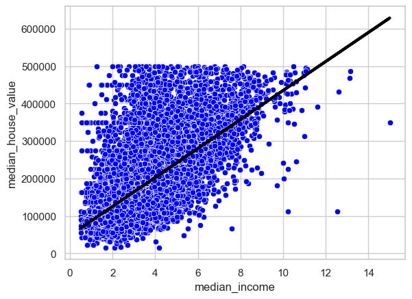

```python
# plot the regression line against the training data
sns.scatterplot(x="median_income", y="median_house_value", data=train, color="blue")
plt.plot(train[["median_income"]], model.predict(train[["median_income"]]), color="black", linewidth=3)
```

### Adding the line parameters (intercept and slope), MSE and MAE to the graph for median house value vs. median income :

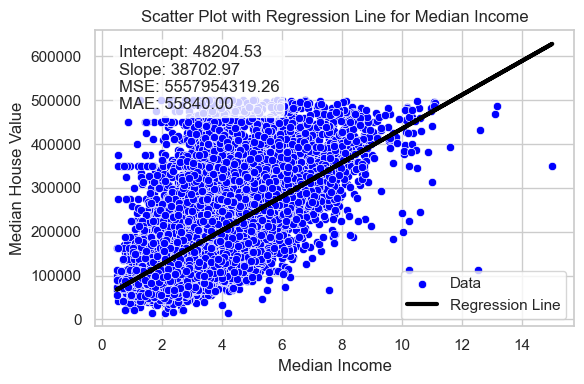

```python
# Predicting the values for median_income
y_pred = model.predict(train[["median_income"]])

# Calculating MSE and MAE of median_house_value vs. median_income
mse = mean_squared_error(train[["median_house_value"]], y_pred)
mae = mean_absolute_error(train[["median_house_value"]], y_pred)

# Creating the scatter plot with Seaborn
plt.figure(figsize=(6, 4))
sns.scatterplot(x="median_income", y="median_house_value", data=train, color="blue", label='Data')

# Plot regression line with Matplotlib
plt.plot(train[["median_income"]], y_pred, color="black", linewidth=3, label='Regression Line')

# identifying the intercept and slope values of the model
intercept = model.intercept_[0]
slope = model.coef_[0][0]

# Add text box with line parameters and error metrics
textstr = f'Intercept: {intercept:.2f}\nSlope: {slope:.2f}\nMSE: {mse:.2f}\nMAE: {mae:.2f}'
plt.text(0.05, 0.95, textstr, transform=plt.gca().transAxes, fontsize=12,
         verticalalignment='top', bbox=dict(boxstyle='round', facecolor='white', alpha=0.8))


plt.xlabel('Median Income') # adding label to the X-axis
plt.ylabel('Median House Value') #adding label to the Y- axis
plt.title('Scatter Plot with Regression Line for Median Income') # adding title to the graph

# Show legend
plt.legend()

# Displaying the plot
plt.tight_layout()
plt.show()
```

### Plotting the line on top of scatter data for median house value vs. population :

```python
12*model1.coef_ +model1.intercept_
```

```
array([[188085.53218256]])
```

```python
model1.predict(X=[[12],[1],[100]])
```

```
array([[188085.53218256],
       [188081.91725556],
       [188114.45159855]])
```

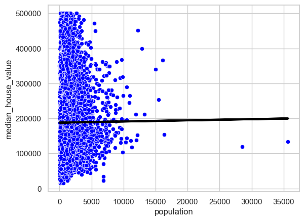

```python
sns.scatterplot(x="population", y="median_house_value", data=train, color="blue")
plt.plot(train[["population"]], model1.predict(train[["population"]]), color="black", linewidth=3)
plt.show()
```

### Adding the line parameters (intercept and slope), MSE and MAE to the graph for median house value vs. population :

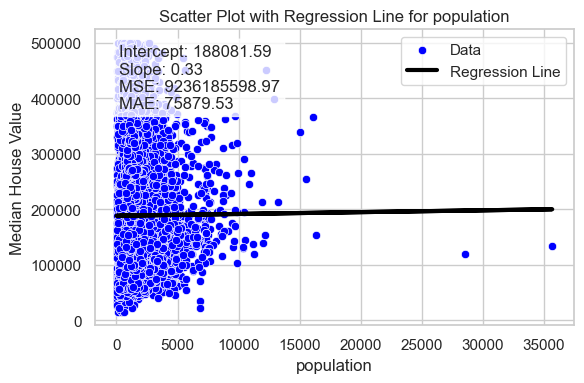

```python
# Predicting the values for median_income
y_pred = model1.predict(train[["population"]])

# Calculating MSE and MAE of the median_house_value vs. population
mse = mean_squared_error(train[["median_house_value"]], y_pred)
mae = mean_absolute_error(train[["median_house_value"]], y_pred)

# Creating scatter plot with Seaborn
plt.figure(figsize=(6, 4))
sns.scatterplot(x="population", y="median_house_value", data=train, color="blue", label='Data')

# Plot regression line with Matplotlib
plt.plot(train[["population"]], y_pred, color="black", linewidth=3, label='Regression Line')

# identifying the intercept and slope from the model1
intercept = model1.intercept_[0]
slope = model1.coef_[0][0]

# Add text box with line parameters and error metrics
textstr = f'Intercept: {intercept:.2f}\nSlope: {slope:.2f}\nMSE: {mse:.2f}\nMAE: {mae:.2f}'
plt.text(0.05, 0.95, textstr, transform=plt.gca().transAxes, fontsize=12,
         verticalalignment='top', bbox=dict(boxstyle='round', facecolor='white', alpha=0.8))


plt.xlabel('population') #adding label to the x axis
plt.ylabel('Median House Value') #adding label to the y axis
plt.title('Scatter Plot with Regression Line for population') # adding title to the graph

# Show legend
plt.legend()

# Displaying plot
plt.tight_layout()
plt.show()
```

### Plotting the line on top of scatter data for median house value vs. households :

```python
12*model2.coef_ + model2.intercept_
```

```
array([[177418.79724925]])
```

```python
model2.predict(X=[[12],[1],[100]])
```

```
array([[177418.79724925],
       [177169.91426426],
       [179409.86112921]])
```

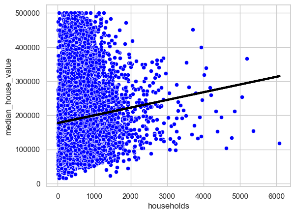

```python
sns.scatterplot(x="households", y="median_house_value", data=train, color="blue")
plt.plot(train[["households"]], model2.predict(train[["households"]]), color="black", linewidth=3)
plt.show()
```

### Adding the line parameters (intercept and slope), MSE and MAE to the graph for median house value vs. households :

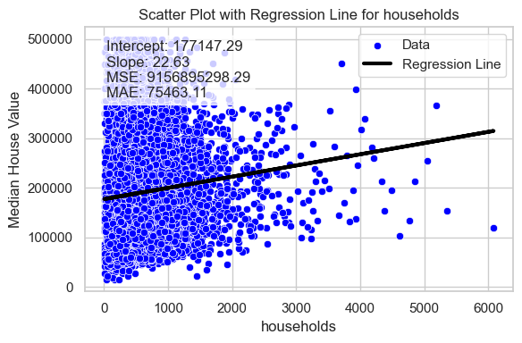

```python
# Predicting the values for median_income
y_pred = model2.predict(train[["households"]])

# Calculating the MSE and MAE of the median_house_value vs. households
mse = mean_squared_error(train[["median_house_value"]], y_pred)
mae = mean_absolute_error(train[["median_house_value"]], y_pred)

# Creating scatter plot with Seaborn
plt.figure(figsize=(6, 4))
sns.scatterplot(x="households", y="median_house_value", data=train, color="blue", label='Data')

# Plot regression line with Matplotlib
plt.plot(train[["households"]], y_pred, color="black", linewidth=3, label='Regression Line')

# identifying the intercept and slope from the model2
intercept = model2.intercept_[0]
slope = model2.coef_[0][0]

# Add text box with line parameters and error metrics
textstr = f'Intercept: {intercept:.2f}\nSlope: {slope:.2f}\nMSE: {mse:.2f}\nMAE: {mae:.2f}'
plt.text(0.05, 0.95, textstr, transform=plt.gca().transAxes, fontsize=12,
         verticalalignment='top', bbox=dict(boxstyle='round', facecolor='white', alpha=0.8))


plt.xlabel('households') # adding label to the x axis
plt.ylabel('Median House Value') # adding label to the y axis
plt.title('Scatter Plot with Regression Line for households') # adding title to the model2

# Show legend
plt.legend()

# Displaying plot
plt.tight_layout()
plt.show()
```

### Summary:

The correlation between the independent variables and the median house value varies, according to the regression analysis. The model with the lowest Mean Squared Error (MSE) and Mean Absolute Error (MAE) is the one with the strongest connection, based on median income. The population variable, on the other hand, has less predictive potential. These findings underscore the significance of income levels in influencing house prices and can help shape future real estate development initiatives.